# capstone-proj2

# 3. CORRELATION ANALYSIS AND HEAT MAP

```python
healthcare.corr()
```

|  | Pregnancies | Glucose | BloodPressure | SkinThickness | Insulin | BMI | DiabetesPedigreeFunction | Age | Outcome |
| --- | --- | --- | --- | --- | --- | --- | --- | --- | --- |
| Pregnancies | 1.000000 | 0.127957 | 0.208615 | 0.081770 | 0.055478 | 0.021546 | -0.033523 | 0.544341 | 0.221898 |
| Glucose | 0.127957 | 1.000000 | 0.218615 | 0.192677 | 0.420301 | 0.231470 | 0.137100 | 0.266591 | 0.492911 |
| BloodPressure | 0.208615 | 0.218615 | 1.000000 | 0.191892 | 0.072041 | 0.281132 | -0.002378 | 0.324915 | 0.165723 |
| SkinThickness | 0.081770 | 0.192677 | 0.191892 | 1.000000 | 0.158133 | 0.543275 | 0.102188 | 0.126107 | 0.214873 |
| Insulin | 0.055478 | 0.420301 | 0.072041 | 0.158133 | 1.000000 | 0.166946 | 0.099170 | 0.136050 | 0.214278 |
| BMI | 0.021546 | 0.231470 | 0.281132 | 0.543275 | 0.166946 | 1.000000 | 0.153506 | 0.025744 | 0.312249 |
| DiabetesPedigreeFunction | -0.033523 | 0.137100 | -0.002378 | 0.102188 | 0.099170 | 0.153506 | 1.000000 | 0.033561 | 0.173844 |
| Age | 0.544341 | 0.266591 | 0.324915 | 0.126107 | 0.136050 | 0.025744 | 0.033561 | 1.000000 | 0.238356 |
| Outcome | 0.221898 | 0.492911 | 0.165723 | 0.214873 | 0.214278 | 0.312249 | 0.173844 | 0.238356 | 1.000000 |

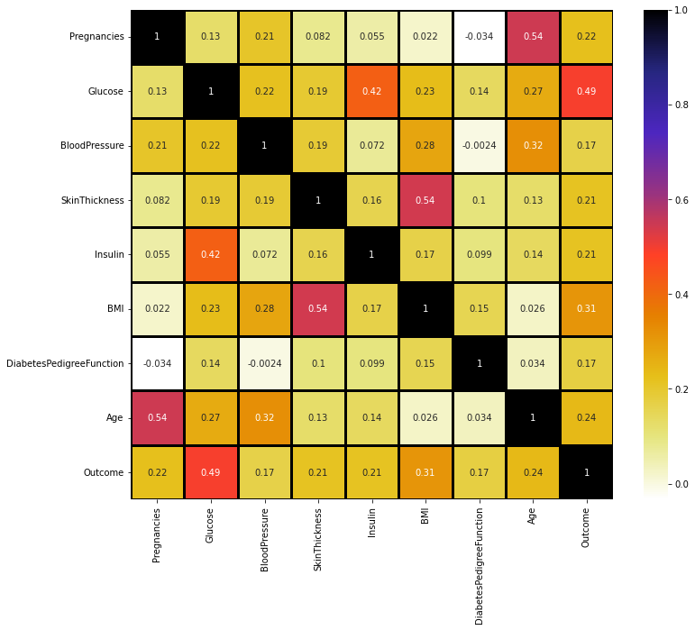

```python
plt.figure(figsize=(12,10))
sns.heatmap(healthcare.corr(),cmap=plt.cm.CMRmap_r,annot=True,linewidths=3,linecolor='black')
```

# DATA MODELING:

# 1. strategies for model building

The following steps are used to be analyze a business problem. 1.Understand the business problem. 2.Understand and identify data. 3.Collect and prepare data. 4.Determine the model's features and train it. 5.Evaluate the model's performance and establish benchmarks. 6.Put the model in operation and make sure it works well 7.Implement the model to check the accuracy of data.

# 2.CLASSIFICATION ALGORITHM-Logistic Regression

```python
healthcare.columns
```

```
Index(['Pregnancies', 'Glucose', 'BloodPressure', 'SkinThickness', 'Insulin',
       'BMI', 'DiabetesPedigreeFunction', 'Age', 'Outcome'],
      dtype='object')
```

```python
convert_zero_values=['Glucose', 'BloodPressure', 'SkinThickness', 'Insulin',
       'BMI']
for column in convert_zero_values:
    healthcare[column]=healthcare[column].replace(0,np.NaN)
    mean=int(healthcare[column].mean(skipna=True))
    healthcare[column]=healthcare[column].replace(np.NaN,mean)
```

```python
healthcare['SkinThickness']
```

```
0      35.0
1      29.0
2      29.0
3      23.0
4      35.0
       ...
763    48.0
764    27.0
765    23.0
766    29.0
767    31.0
Name: SkinThickness, Length: 768, dtype: float64
```

```python
from sklearn.model_selection import train_test_split
x=healthcare.iloc[:,0:8]
y=healthcare.iloc[:,8]
X_train, X_test, y_train, y_test = train_test_split(x, y, test_size = 0.25, random_state = 0)
```

```python
from sklearn.preprocessing import StandardScaler
sc= StandardScaler()
X_train = sc.fit_transform(X_train)
X_test = sc.transform(X_test)
```

```python
print('X_train',X_train.shape)
print('X_test',X_test.shape)
print('y_train',y_train.shape)
print('y_test',y_test.shape)
```

```
X_train (576, 8)
X_test (192, 8)
y_train (576,)
y_test (192,)
```

```python
from sklearn.linear_model import LogisticRegression

logreg = LogisticRegression()
logreg.fit(X_train, y_train)
```

```
LogisticRegression()
```

```python
y_pred = logreg.predict(X_test)
```

```python
from sklearn.metrics import confusion_matrix
cm = confusion_matrix(y_test, y_pred)

print ("Confusion Matrix : \n", cm)
```

```
Confusion Matrix :
 [[117  13]
 [ 28  34]]
```

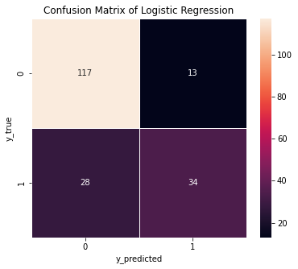

```python
f, ax = plt.subplots(figsize = (6,5))
sns.heatmap(cm, annot = True, linewidths = 0.5, color = "red", fmt = ".0f", ax=ax)
plt.xlabel("y_predicted")
plt.ylabel("y_true")
plt.title("Confusion Matrix of Logistic Regression")
plt.show()
```

```python
from sklearn.metrics import accuracy_score
accuracy = logreg.score(X_test, y_test)
print("Logistic Regression accuracy is :",accuracy*100)
```

```
Logistic Regression accuracy is : 78.64583333333334
```

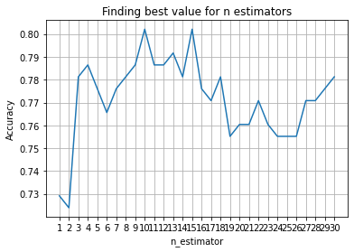

```python
#plotting a graph for n_neighbours
from sklearn import metrics
from sklearn.neighbors import KNeighborsClassifier

xaxis =list(range(1,31))
acc=pd.Series()
x=range(1,31)

for i in list(range(1,31)):
    knn_model=KNeighborsClassifier(n_neighbors=i)
    knn_model.fit(X_train,y_train)
    prediction=knn_model.predict(X_test)
    acc=acc.append(pd.Series(metrics.accuracy_score(prediction,y_test)))

plt.plot(xaxis,acc)
plt.xticks(x)
plt.title("Finding best value for n estimators")
plt.xlabel("n_estimator")
plt.ylabel("Accuracy")
plt.grid()
plt.show()
```

```python
from sklearn.neighbors import KNeighborsClassifier
kn=KNeighborsClassifier(n_neighbors=11,metric='euclidean',p=2)
kn.fit(X_train,y_train)
```

```
KNeighborsClassifier(metric='euclidean', n_neighbors=11)
```

```python
y_pred=kn.predict(X_test)
```

```python
cm=confusion_matrix(y_test,y_pred)
print("confusion matrix: \n",cm)
```

```
confusion matrix:
 [[113  17]
 [ 24  38]]
```

```python
from sklearn.metrics import f1_score
f1_score=f1_score(y_test,y_pred)
print("f1_score: \n",f1_score)
```

```
f1_score:
 0.6495726495726496
```

```python
accuracy=accuracy_score(y_test,y_pred)
print("Accuracy: \n",accuracy*100)
```

```
Accuracy:
 78.64583333333334
```

```python
#Using support verctor machine
from sklearn.svm import SVC
svc=SVC(kernel='linear',random_state=42)
svc.fit(X_train,y_train)
```

```
SVC(kernel='linear', random_state=42)
```

```python
#DEcision tree alsogorithm
from sklearn.tree import DecisionTreeClassifier
dectree=DecisionTreeClassifier()
dectree.fit(X_train,y_train)
```

```
DecisionTreeClassifier()
```

```python
#Making Prediction
y_predict_logistic=logreg.predict(X_test)
y_predict_knn=kn.predict(X_test)
y_predict_svm=svc.predict(X_test)
y_predict_decisiontree=dectree.predict(X_test)
```

```python
#accuracy
from sklearn.metrics import accuracy_score
accuracy_logistic=accuracy_score(y_test,y_predict_logistic)
accuracy_knn=accuracy_score(y_test,y_predict_knn)
accuracy_svm=accuracy_score(y_test,y_predict_svm)
accuracy_dectree=accuracy_score(y_test,y_predict_decisiontree)
```

```python
#display accuracy
print("Logistic Regression :", round(accuracy_logistic*100))
print("K Neraest Neighbors :",round(accuracy_knn*100))
print("Support Vector Classifier :",round(accuracy_svm*100))
print("Decision Tree Classifier :",round(accuracy_dectree *100))
```

```
Logistic Regression : 79
K Neraest Neighbors : 79
Support Vector Classifier : 78
Decision Tree Classifier : 74
```

# OBSERVATIONS

As compared with few algorithm we got highest accuracy as "79%"

to increase the more accuracy we also need to follow few methods in preprocessing.

1.Ensembled method or Oversampling minority class required to use to get rid from imbalanced dataset.

# CLASSIFICATIN REPORT

```python
from sklearn import metrics
from sklearn.metrics import classification_report
y_pred=np.around(logreg.predict(X_test))

print(metrics.classification_report(y_test,y_pred))
```

```
              precision    recall  f1-score   support

           0       0.81      0.90      0.85       130
           1       0.72      0.55      0.62        62

    accuracy                           0.79       192
   macro avg       0.77      0.72      0.74       192
weighted avg       0.78      0.79      0.78       192
```

# AUC (ROC curve)

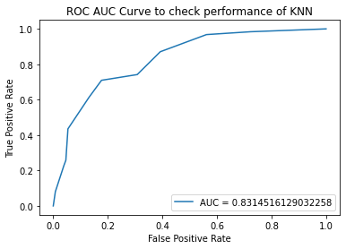

```python
from sklearn.metrics import roc_curve
y_predict_proba=kn.predict_proba(X_test)[ : : ,1]
fpr, tpr, thresholds = roc_curve(y_test, y_predict_proba)
auc = metrics.roc_auc_score(y_test, y_predict_proba)


#Create ROC Curve
plt.plot(fpr,tpr,label="AUC = "+str(auc))
plt.ylabel("True Positive Rate")
plt.xlabel("False Positive Rate")
plt.title("ROC AUC Curve to check performance of KNN")
plt.legend(loc=4)
plt.show()
```

# OBSERVATIONS:

ROC (Receiver Operating Characteristic) Curve tells us about how good the model can distinguish between two things (e.g If a patient has a disease or no).

It is an graphical representation of model performance.so AUC(Area under the curve) must required as high as possible.

AUC ROC useful when model is binary classification problem(which have only 2 possible outcomes or 2 classes)

Better models can accurately distinguish between the two. Whereas, a poor model will have difficulties in distinguishing between the two

in our case AUC Score is-83 ,for good model AUC must required more than 95%